```r
install.packages('TSA')
install.packages('lmtest')
install.packages('urca')
install.packages('depmixS4')
install.packages('markovchain')
library(devtools)
install_github("cran/fOptions")
library(TSA)
library(lmtest)
library(urca)
library(depmixS4)
library(markovchain)
library(fOptions)
```

# Вопрос 1.

Идентифицировать и оценить наиболее адекватную $\text{ARMA}$ модель. Выбор модели обосновать.

```r
data1 = read.csv('question_1.csv')
head(data1)
```

A data.frame: 6 × 2

|  | X <int> | x <dbl> |
| --- | --- | --- |
| 1 | 1 | -0.05150143 |
| 2 | 2 | 1.27982981 |
| 3 | 3 | -1.94777180 |
| 4 | 4 | -0.56169870 |
| 5 | 5 | 4.14780357 |
| 6 | 6 | 1.76098845 |

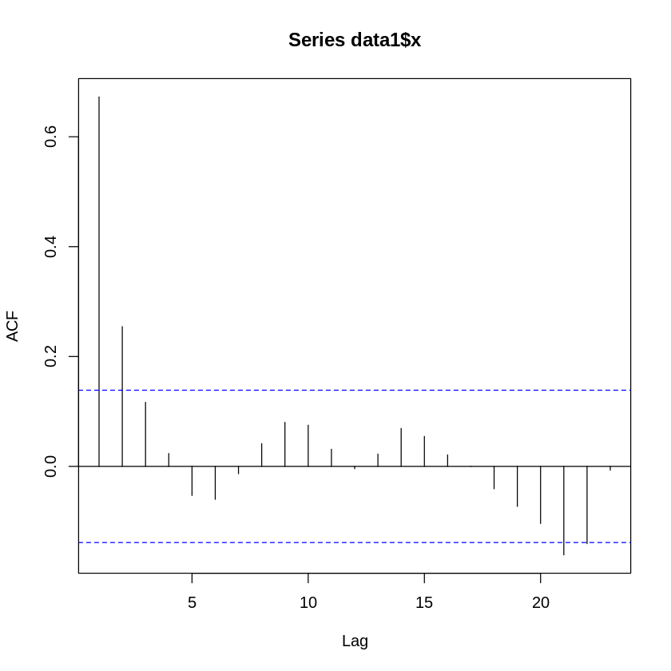

```r
acf(data1$x)
```

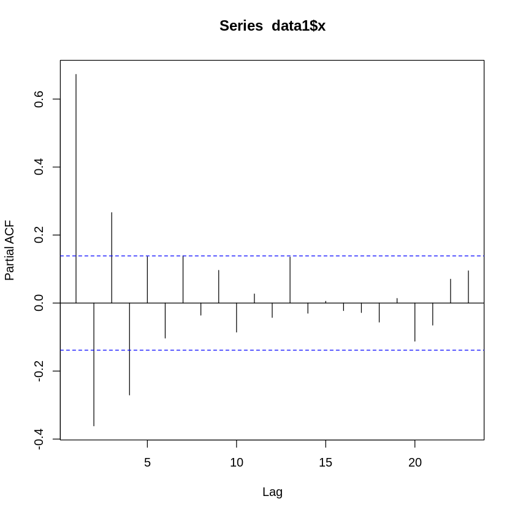

```r
pacf(data1$x)
```

```r
for (p in 0:4) {
    for (q in 0:4) {
        if (p + q > 0) {
            arma_model = arima(data1$x, order=c(p, 0, q), method='ML')
            print(c(p, q, arma_model$aic))
        }

    }
}
```

```
[1]   0.000   1.000 833.705
[1]   0.0000   2.0000 821.1796
[1]   0.0000   3.0000 820.0204
[1]   0.0000   4.0000 821.6238
[1]   1.0000   0.0000 897.9072
[1]   1.0000   1.0000 818.1636
[1]   1.0000   2.0000 819.2554
[1]   1.0000   3.0000 821.2215
[1]   1.0000   4.0000 823.1897
[1]   2.0000   0.0000 872.1094
[1]   2.0000   1.0000 819.2313
[1]   2.0000   2.0000 821.2251
[1]   2.0000   3.0000 823.2246
[1]   2.0000   4.0000 823.4584
[1]   3.0000   0.0000 858.9314
[1]   3.0000   1.0000 821.2263
[1]   3.0000   2.0000 823.2255
[1]   3.0000   3.0000 823.2251
[1]   3.000   4.000 825.217
[1]   4.0000   0.0000 844.6148
[1]   4.0000   1.0000 823.1775
[1]   4.0000   2.0000 824.4587
```

```
[1]   4.0000   3.0000 826.1353
[1]   4.0000   4.0000 826.6704
```

По критерию Акаике лучшей моделью оказалась $\text{ARMA}(1, 1)$.

```r
arma_model <- arima(data1$x, order=c(1, 0, 1), method='ML')
```

```r
coeftest(arma_model)
```

```
z test of coefficients:

          Estimate Std. Error z value  Pr(>|z|)
ar1       0.290833   0.067766  4.2917 1.773e-05 ***
ma1       0.999999   0.023459 42.6269 < 2.2e-16 ***
intercept 0.284026   0.360544  0.7878    0.4308
---
Signif. codes:  0 ‘***’ 0.001 ‘**’ 0.01 ‘*’ 0.05 ‘.’ 0.1 ‘ ’ 1
```

```r
Box.test(arma_model$residuals, lag=12, type="Ljung-Box", fitdf=2)
```

```
	Box-Ljung test

data:  arma_model$residuals
X-squared = 3.6475, df = 10, p-value = 0.9619
```

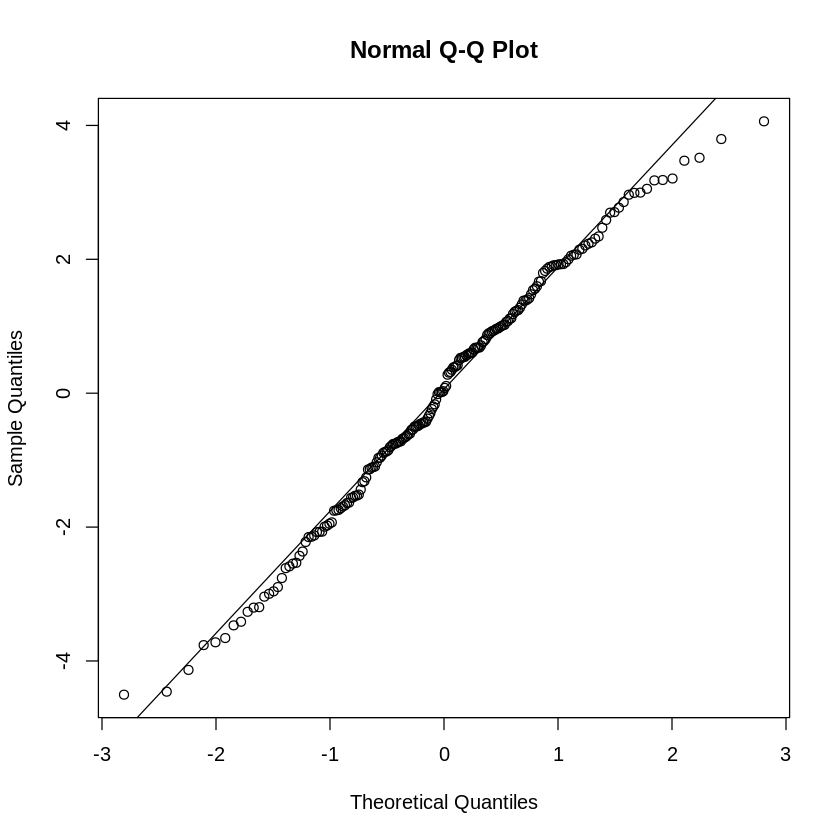

```r
qqnorm(arma_model$residuals)
qqline(arma_model$residuals)
```

# Вопрос 2.

Является ли стационарной модель вида:

$x_t = 0.6x_{t - 1} - 0.2x_{t - 2} + 0.6x_{t - 3} + \epsilon _t$

$\text{AR}(p)$ модель является стационарной $\Leftrightarrow$ корни характеристического уравнения $1 - \phi_1B - ... - \phi_pB^p = 0$ лежат вне единичной окружности.

```r
p <- polyroot(c(1, -0.6, 0.2, -0.6))
print(p)
print(all (abs(p) > 1))
```

```
[1]  1.000000+0.000000i -0.333333+1.247219i -0.333333-1.247219i
[1] FALSE
```

# Вопрос 3.

Идентифицировать и оценить наиболее адекватную ARMA модель. Выбор модели обосновать.

```r
data3 = read.csv('question_3.csv')
head(data3)
```

A data.frame: 6 × 2

|  | X <int> | x <dbl> |
| --- | --- | --- |
| 1 | 1 | 1.784468 |
| 2 | 2 | 1.945506 |
| 3 | 3 | 2.001424 |
| 4 | 4 | 2.776237 |
| 5 | 5 | 3.244034 |
| 6 | 6 | 2.528391 |

```r
data3 <- data3$x
```

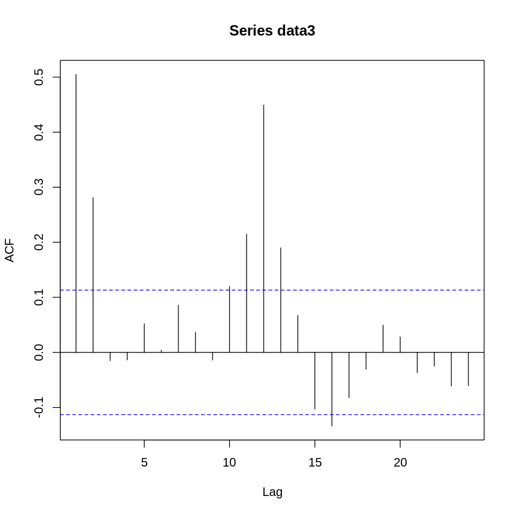

```r
acf(data3)
```

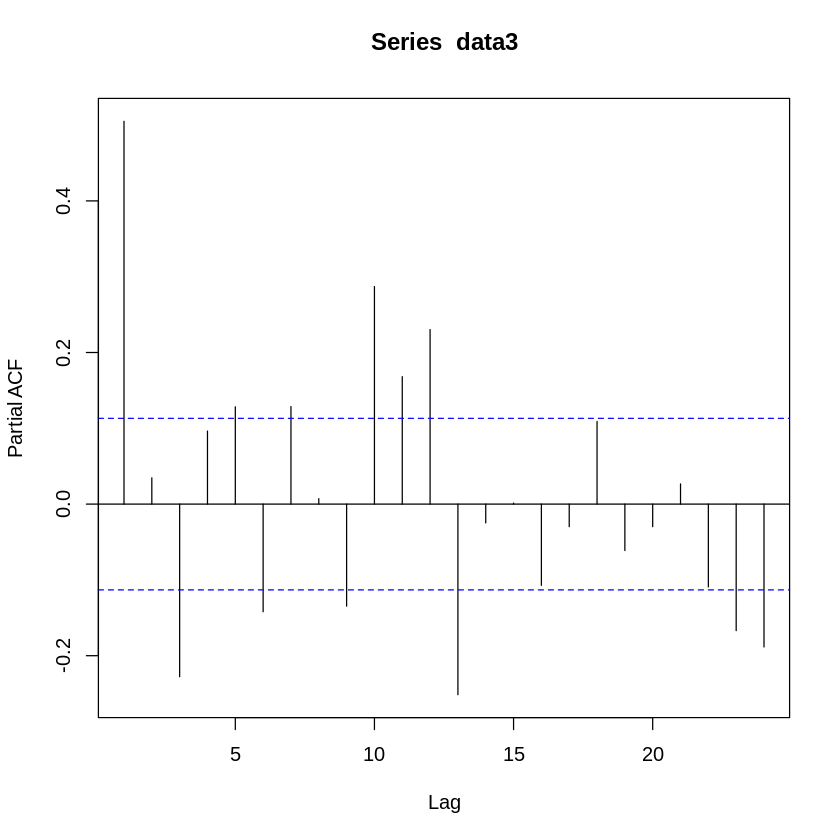

```r
pacf(data3)
```

https://shiny.ilykei.com/ANDoynikov/ARMAMODEL4/

```r
for (p in 0:5){
    for (q in 0:5){
        tryCatch({model <- arima(data3, order=c(3, 0, 3), seasonal = list(order= c(p, 0, q), period=12), method='ML')
        print(paste(p, q, model$aic))},
        error=function(error_message) {

        })
    }
}
```

```
[1] "0 0 974.436558007273"
[1] "0 1 856.999059106368"
[1] "0 2 864.105653542328"
[1] "0 3 863.92626437196"
```

```
[1] "0 4 865.920453585946"
[1] "0 5 865.658101720949"
[1] "1 0 910.758776952672"
[1] "1 1 864.199672483374"
```

```
[1] "1 2 858.297503546216"
[1] "1 3 863.420626424949"
[1] "1 4 865.172057785348"
[1] "1 5 865.414824178882"
[1] "2 0 882.302553337392"
[1] "2 1 864.419736690684"
```

По критерию Акакике лучшей моделью оказалась $\text{SARMA}(3, 0, 3)(0, 0, 1)$.

```r
sarma_model = arima(data3, order=c(3, 0, 3), seasonal=c(0, 0, 1), method='ML')
```

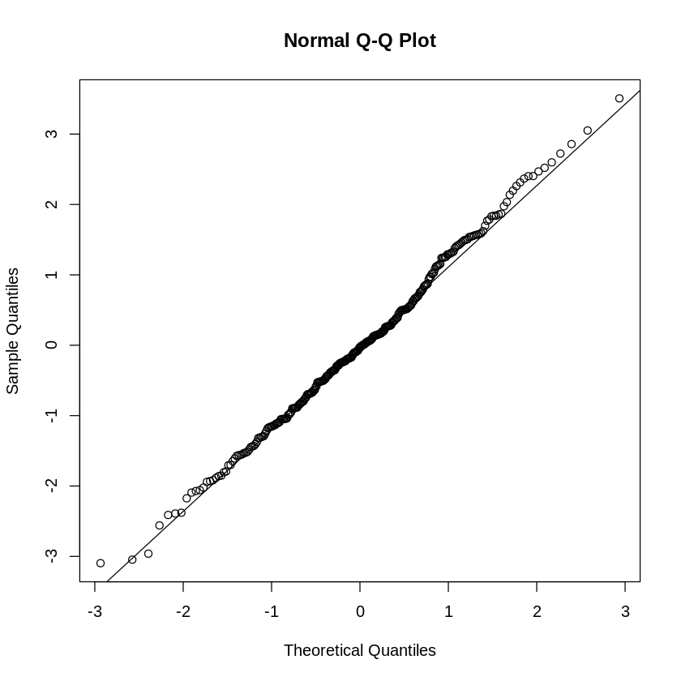

```r
resid = sarma_model$residuals
qqnorm(resid)
qqline(resid)
```

# Вопрос 4.

Определить задержку между рядами $x,y$. Ответить на вопрос, какой из рядов опережает другой.

```r
data4 = read.csv('question_4.csv')
head(data4)
```

A data.frame: 6 × 2

|  | x <dbl> | y <dbl> |
| --- | --- | --- |
| 1 | 0.76113745 | 0.09121127 |
| 2 | 0.81808598 | 0.16027269 |
| 3 | -1.57177767 | -1.84896909 |
| 4 | 0.40975434 | 1.90011466 |
| 5 | -1.04338995 | 0.67390720 |
| 6 | -0.05926706 | -1.11116425 |

Кросс-ковариационная функция:

$ccf_{xy}(m) = \mathbb{E}(x_t - \mu_x)(y_{t + m} - \mu_y)$

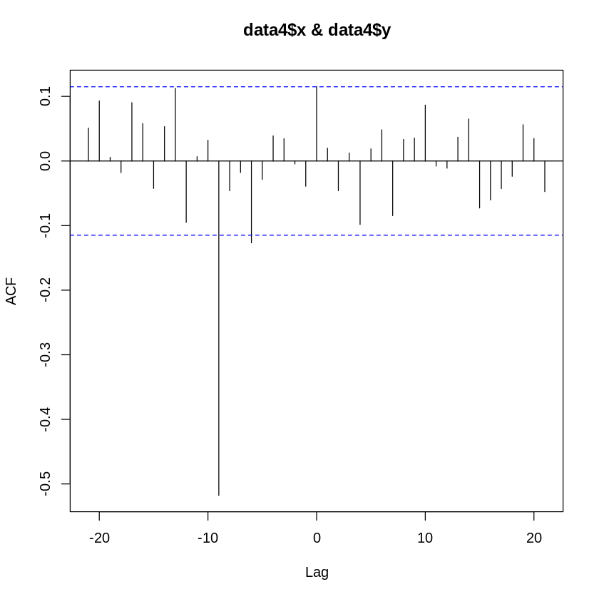

```r
ccf(data4$x, data4$y)
```

$m < 0 \implies x$ опережает $y$.

# Вопрос 5.

Является ли стационарной многомерная модель рядов:

$\text{VAR}(p)$ является стационарной $⇔$ все собственные значения матрицы $F =\begin{bmatrix} \Phi_1 & ... & \Phi_p\\ I & 0 & 0\\ \\ ... & ... & ... \\ 0 & I & 0\end{bmatrix}$ лежат внутри единичной окружности.

```r
Phi1 <- c(-0.1,-0.1, 0)
Phi1 <- rbind(Phi1,c(0.1,0.1,0.3))
Phi1 <- rbind(Phi1,c(0.1,0.3,0.2))
Phi1
```

A matrix: 3 × 3 of type dbl

| Phi1 | -0.1 | -0.1 | 0.0 |
| --- | --- | --- | --- |
|  | 0.1 | 0.1 | 0.3 |
|  | 0.1 | 0.3 | 0.2 |

```r
Phi2 <- c(-0.2,-0.3, 0.2)
Phi2 <- rbind(Phi2,c(0, 0.3, 0.2))
Phi2 <- rbind(Phi2,c(0.6, -0.4, 0.6))
Phi2
```

A matrix: 3 × 3 of type dbl

| Phi2 | -0.2 | -0.3 | 0.2 |
| --- | --- | --- | --- |
|  | 0.0 | 0.3 | 0.2 |
|  | 0.6 | -0.4 | 0.6 |

```r
I = diag(1, 3, 3)
IZ = cbind(I, diag(0, 3, 3))
IZ
```

A matrix: 3 × 6 of type dbl

| 1 | 0 | 0 | 0 | 0 | 0 |
| --- | --- | --- | --- | --- | --- |
| 0 | 1 | 0 | 0 | 0 | 0 |
| 0 | 0 | 1 | 0 | 0 | 0 |

```r
F_matr = cbind(Phi1, Phi2)
F_matr = rbind(F_matr, IZ)
F_matr
```

A matrix: 6 × 6 of type dbl

| Phi1 | -0.1 | -0.1 | 0.0 | -0.2 | -0.3 | 0.2 |
| --- | --- | --- | --- | --- | --- | --- |
|  | 0.1 | 0.1 | 0.3 | 0.0 | 0.3 | 0.2 |
|  | 0.1 | 0.3 | 0.2 | 0.6 | -0.4 | 0.6 |
|  | 1.0 | 0.0 | 0.0 | 0.0 | 0.0 | 0.0 |
|  | 0.0 | 1.0 | 0.0 | 0.0 | 0.0 | 0.0 |
|  | 0.0 | 0.0 | 1.0 | 0.0 | 0.0 | 0.0 |

```r
eval = eigen(F_matr, only.values=TRUE)
abs(eval$values)
```

1. 0.872589303586077

2. 0.872589303586077

3. 0.827851369236254

4. 0.600134278998068

5. 0.600134278998068

6. 0.546201232722753

```r
all(abs(eval$values) < 1)
```

TRUE

# Вопрос 6.

Коинтегрированы ли предложенные ряды? Проверить гипотезу о порядке коинтеграции рядов.

Пусть $y_t = (y_t^1, ..., y_t^n),$ где $y_t^i \in I(1)$. Тогда компоненты этого многомерного ряда называются **коинтегрированными**, если $\exists a \in \mathbb{R}^n : a^T y_t \in I(0)$.

```r
data6 <- read.csv('question_6.csv')
head(data6)
```

A data.frame: 6 × 4

|  | X1 <dbl> | X2 <dbl> | X3 <dbl> | X4 <dbl> |
| --- | --- | --- | --- | --- |
| 1 | 8.568350 | 9.141917 | 4.435812 | 9.409734 |
| 2 | 5.473472 | 5.457342 | 9.390012 | 6.847860 |
| 3 | 10.795071 | 4.388311 | 6.896335 | 9.961502 |
| 4 | 6.384992 | 6.870392 | 7.977238 | 11.749531 |
| 5 | 6.021424 | 4.016108 | 4.725525 | 11.456281 |
| 6 | 5.817878 | 7.633890 | 6.478650 | 7.482816 |

$\text{ecdet}$ - нужен ли сдвиг $b$ в преобразовании $A^Ty_t + b= z_t$

$\text{spec}$ - метод

```r
vecm <- ca.jo(data6, ecdet="none", type="eigen", K=3, spec="longrun")
summary(vecm)
```

```
######################
# Johansen-Procedure #
######################

Test type: maximal eigenvalue statistic (lambda max) , with linear trend

Eigenvalues (lambda):
[1] 0.38222613 0.22439664 0.16763292 0.01631707

Values of teststatistic and critical values of test:

           test 10pct  5pct  1pct
r <= 3 |   4.89  6.50  8.18 11.65
r <= 2 |  54.49 12.91 14.90 19.19
r <= 1 |  75.47 18.90 21.07 25.75
r = 0  | 143.04 24.78 27.14 32.14

Eigenvectors, normalised to first column:
(These are the cointegration relations)

           X1.l3       X2.l3       X3.l3    X4.l3
X1.l3  1.0000000  1.00000000  1.00000000 1.000000
X2.l3  0.4533757 -0.33488628 -1.88801212 4.918347
X3.l3 -1.5810930 -0.01869977 -0.07399083 4.704580
X4.l3  0.1402701 -0.66265895  0.86809667 2.196378

Weights W:
(This is the loading matrix)

          X1.l3       X2.l3      X3.l3        X4.l3
X1.d -0.5611653 -0.32646842 -0.1172642 -0.001778708
X2.d -0.3653586  0.17127048  0.1136587 -0.003548688
X3.d  0.5418005  0.05375908 -0.1300136 -0.003593110
X4.d -0.4145640  0.45274114 -0.1305788  0.001234545
```

Тем самым, гипотеза о порядке коинтеграции $h \le 3$ не отвергается.

# Вопрос 7.

Инвестор продал 10 колл и 10 пут опционов на акцию компании XXX, цена которой в данный момент - 1000 рублей, страйк - 1000 рублей (такой портфель называется страдл), срок до экспирации - полгода, волатильность в данный момент - 40%, ставка безрисковая - 15%, дивидендов нет. Найти оптимальную цену (цена по модели Black-Sholes), полученную за данный портфель. Сколько акций компании XXX надо купить или продать, чтобы застраховать данный портфель опционов от изменения цен. (т.е. найти δ нейтральный портфель акций и опционов)

```r
n_call <- 10
n_put <- 10
S <- 1000
X <- 1000
T <- 0.5
sigma <- 0.4
r <- 0.15
b <- 0
```

```r
call <- GBSOption('c', S=S, X=X, Time=T, sigma=sigma, r=r, b=b)
put <- GBSOption('p', S=S, X=X, Time=T, sigma=sigma, r=r, b=b)
res_price <- n_call * call@price + n_put * put@price
res_price
```

2086.7357658623

```r
Selection = 'Delta'
```

```r
call_Delta <- GBSGreeks(Selection=Selection, TypeFlag='c',S=S, X=X, Time=T, sigma=sigma, r=r, b=b)
put_Delta <- GBSGreeks(Selection=Selection, TypeFlag='p',S=S, X=X, Time=T, sigma=sigma, r=r, b=b)
res_Delta <- n_call * call_Delta + n_put * put_Delta
res_Delta
```

1.04336788293115

```r
put_Delta
```

-0.411703349017719

```r
call_Delta
```

0.516040137310834

# Вопрос 10.

В файле question_10.csv часовые данные по объемам торгов акциями Газпрома (реальные данные). Проверить:

1. Есть ли сезонность в данных?
2. Каков период сезонности ?
3. Построить прогноз данных на период сезонности методом сезонной модели Хольта-Уинтерса
4. В каких наблюдениях сезонного эффекта наибольший и наименьший объем сделок? По этим номерам можно узнать во сколько по времени это происходит, если знать, что данные начинаются с 11:00. Произнесите правильно на русском языке как будете докладывать начальству на работе (зависит от типа модели) про наибольший и наименьший объем.

```r
data10 <- read.csv('question_10.csv')
head(data10)
```

A data.frame: 6 × 1

|  | VOL <int> |
| --- | --- |
| 1 | 3544410 |
| 2 | 954800 |
| 3 | 3218600 |
| 4 | 1966950 |
| 5 | 1090620 |
| 6 | 3640710 |

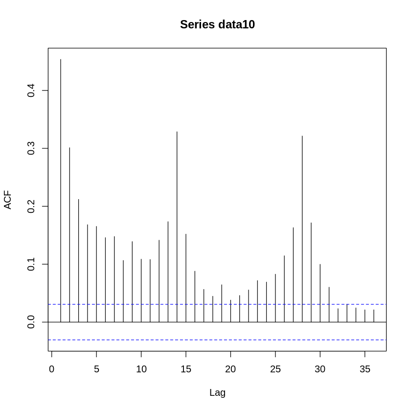

```r
acf(data10)
```

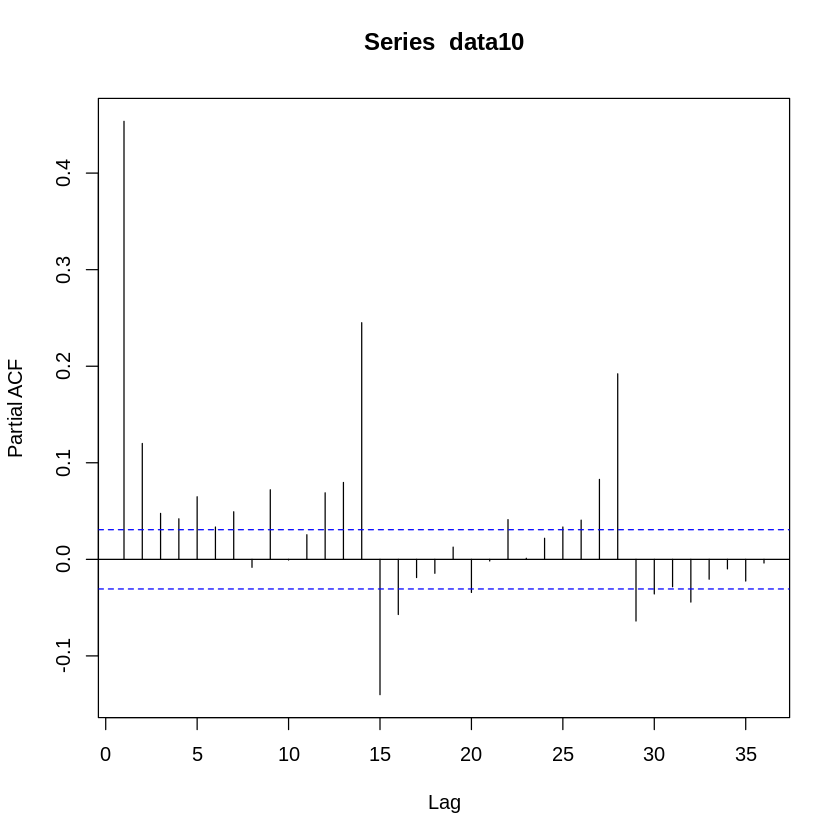

```r
pacf(data10)
```

По графикам acf и pacf можно сделать вывод о наличии сезонности (период сезонности $p = 14$)

```r
data10 = ts(data10, frequency=14)
```

```r
model <- HoltWinters(data10, seasonal='mult')
pred <- predict(model, n.ahead=14)
```

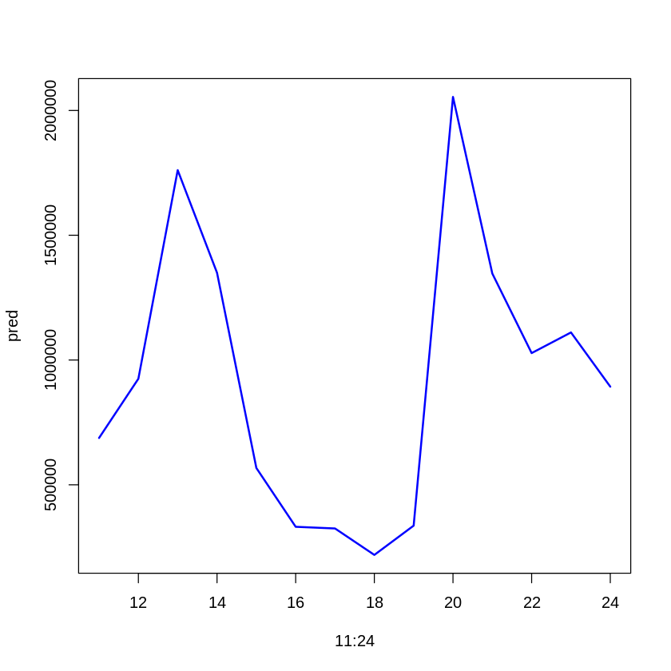

```r
plot(x=11:24, y=pred, type='l', lwd=2, col='blue')
```

Наибольший объём сделок заключается в 20:00, наименьший - 18:00.

# Вопрос 11.

В файле question_10.csv часовые данные по результатам торго акциями Газпрома (реальные данные). Для ряда данных Close найти:

1. Ряд доходностей
2. Матрицу переходных вероятностей за один шаг по времени скрытой цепи Маркова для трех режимов доходностей
3. Стационарное распределение вероятностей.

```r
data11 = read.csv('question_10.csv')
head(data11)
```

A data.frame: 6 × 1

|  | VOL <int> |
| --- | --- |
| 1 | 3544410 |
| 2 | 954800 |
| 3 | 3218600 |
| 4 | 1966950 |
| 5 | 1090620 |
| 6 | 3640710 |

```r
rates <- data11$VOL[2:length(data11$VOL)] / data11$VOL[1:(length(data11$VOL) - 1)] - 1
rates
```

3. -0.388880258497483

4. -0.445527339281629

5. 2.33820212356274

6. 0.029458539680447

7. -0.557433910714095

8. -0.57129593903733

9. -0.725973843341302

10. 0.425382325772349

11. -0.081908190819082

12. -0.175803921568627

13. -0.315839558452681

14. 46.2776270950692

15. -0.738780973955767

16. -0.215319465249074

17. -0.0637783295775861

18. -0.460419301674907

19. 0.950888607918626

20. 0.163779355543419

21. -0.0677967162236572

22. 0.370892932655842

23. -0.815738578220401

24. -0.325246459224617

25. 0.357657622179341

26. -0.470920957215373

27. -0.0304276315789473

28. 25.830138535482

29. -0.390287697764552

30. -0.512773804626983

31. -0.0770949799937569

32. -0.182674937927111

33. 3.52358335292735

34. -0.543374846664033

35. -0.683061427992514

36. 1.65227635151637

37. -0.893590514416332

38. 0.114023924662764

39. 0.168288782270962

40. 0.612132352941176

41. -0.740629321429438

42. 18.8639042185015

43. 1.38126809973395

44. 0.960816534769764

45. -0.558480850278495

46. 0.661833431551249

47. -0.633109020086482

48. -0.40679121727175

49. -0.350382388046505

50. 0.620541486414232

51. -0.780643922806049

52. -0.192036317890937

53. 0.224377200108313

54. -0.419290631133719

55. 0.938779396362944

56. 14.5281392722094

57. -0.634877664259431

58. -0.192232236047171

59. -0.351476548928778

60. -0.238508597883598

61. 1.72060579741613

62. -0.378742592629542

63. 0.187655764240384

64. -0.142418293230358

65. -0.875660608201001

66. -0.039561777236762

67. 1.54921841994085

68. -0.654934537620153

69. -0.315422945308279

70. 111.291853021135

71. -0.439517237501406

72. 0.282501344614158

73. 0.883287358095137

74. 0.313320307069085

75. 1.79498598089994

76. -0.81674739257592

77. 0.429745389428619

78. -0.16732109415958

79. -0.0537825501885945

80. -0.449879520824055

81. 0.154868763026131

82. -0.241507408099778

83. -0.567606595087178

84. 14.8683418223804

85. -0.574590087873592

86. -0.605535170993071

87. -0.0379178524285593

88. -0.458824905298708

89. -0.454243818619777

90. 1.65124465799068

91. -0.186019783874558

92. -0.511872849081006

93. -0.649457929358913

94. 0.518275379565576

95. -0.150765281952782

96. -0.296763593212775

97. -0.419920100379307

98. 50.6734541657343

99. -0.363355110139832

100. -0.418408435461345

101. -0.581773976412128

102. 3.59323276732589

103. 1.42187458778916

104. -0.57807506063075

105. -0.597222047531823

106. -0.429146670172901

107. -0.686137103043215

108. 0.0782193112811198

109. 0.413600360725194

110. -0.454957991285298

111. 0.527771029791745

112. 13.0239740383642

113. -0.323009139171759

114. -0.665029670710308

115. -0.293857894784688

116. 1.04644187041978

117. -0.464453992438492

118. 0.231000093971715

119. -0.143283475273742

120. -0.633564170892191

121. -0.0817115891699659

122. -0.209973188573698

123. -0.227443175866764

124. -0.350981615055046

125. -0.0330903089682257

126. 53.4842389543048

127. -0.46487612236166

128. -0.161959040428255

129. 0.629858778318833

130. -0.632795601212

131. -0.234284414133833

132. 0.923190614930442

133. -0.615043963673284

134. -0.407354221288618

135. -0.686447050752648

136. 0.988681785669205

137. -0.614591487711132

138. 3.03526139545097

139. -0.0370256163756162

140. 8.65957957788263

141. -0.333532232659562

142. -0.369572341231701

143. -0.569304615898704

144. 0.321136952018168

145. 0.313480557084888

146. -0.405955811122979

147. 0.826975042467006

148. -0.350640545164299

149. -0.532117225670871

150. -0.506490082438407

151. -0.0864513174715231

152. 1.38579782790309

153. -0.326633517753344

154. 13.242524700988

155. -0.663888876211166

156. -0.489436385436483

157. 0.491599756383627

158. -0.344818425120756

159. -0.159693458228785

160. 6.05243640980134

161. -0.774865460236434

162. -0.532767641329512

163. -0.491720618345171

164. -0.156560277596454

165. -0.0179837067209776

166. 4.05301034904702

167. -0.810926732364421

168. 10.4540441974558

169. -0.587883451279466

170. -0.38930328811221

171. 2.33612081689208

172. -0.488317211163742

173. -0.382744968293355

174. 0.849082358994883

175. -0.248696522643209

176. -0.17846495751998

177. 2.63295229328499

178. -0.616173054963049

179. -0.512987129628798

180. -0.127101218084076

181. 1.05465589182908

182. 16.7149647308024

183. -0.524196507955073

184. 0.637976850071381

185. -0.437538134868168

186. -0.592848273508302

187. 0.404881868125167

188. -0.308168959308856

189. -0.319103283510174

190. -0.6812127823992

191. 0.232687557085105

192. -0.71106331227197

193. -0.0540689685021478

194. 0.341287090206127

195. 0.243028194238346

196. 10.1379438098178

197. -0.746345195394142

198. -0.424254345703836

199. 1.41901182703177

200. -0.364248860959462

201. ⋯

202. 0.17315850504395

203. -0.680578901928961

204. -0.0921900468622657

205. -0.0824642123203603

206. -0.435095685276278

207. 0.281879012997206

208. 0.922079772831635

209. -0.111697234480164

210. -0.614061770643024

211. -0.317719430338177

212. 0.273362291617751

213. -0.345890379385055

214. -0.488822799797034

215. 17.6422643174236

216. -0.612960527970016

217. -0.388326066104396

218. -0.0437583171415897

219. -0.281137092717092

220. 1.00375362411045

221. 0.748388647734128

222. -0.69126917828476

223. 0.342669153978018

224. 0.209584248637214

225. -0.441499241996989

226. -0.556724907820867

227. -0.171396923591373

228. -0.0805105052084647

229. 10.5026745302428

230. -0.452002003195574

231. 0.0052830385740148

232. -0.22348770161814

233. -0.34238678998099

234. 0.829953713907869

235. 3.54938503231186

236. -0.645409158161525

237. -0.510730069753351

238. -0.505179689746855

239. -0.249234929898228

240. -0.229958605871015

241. -0.127290260366442

242. -0.0184788997296345

243. 15.0039282378021

244. -0.497564910768273

245. -0.60675422474166

246. 0.436532765712468

247. 1.44522017918066

248. -0.13557710140302

249. -0.386653195125298

250. -0.200238349935125

251. 0.00790328896845294

252. -0.574999621558071

253. -0.0783834162441972

254. -0.384991948470209

255. 0.667113531629661

256. -0.419158667135749

257. 6.94120446482651

258. -0.512718397411102

259. 0.464854319000022

260. -0.38508389972485

261. -0.402198197750912

262. -0.23290942123021

263. 0.458587088915956

264. 1.90584087218743

265. 0.326780063670065

266. -0.28532647280376

267. -0.687044339454268

268. -0.451100231344488

269. 0.156159335058418

270. -0.0480348604564413

271. 7.82060735595334

272. -0.444721979351134

273. -0.505614708791528

274. 0.621756208073438

275. -0.665399739660107

276. -0.0643866997410977

277. 1.77550961273778

278. -0.332044014323447

279. 0.179770714972297

280. -0.343021984937105

281. -0.393307253332258

282. -0.55079520715271

283. 0.15149833518313

284. 0.0136546184738955

285. 6.34424722662441

286. -0.469770533121

287. -0.110369526290086

288. -0.375974382433669

289. 0.654590505234144

290. -0.147811755115061

291. 0.675269309154432

292. -0.07615104832603

293. 1.06878296214183

294. -0.66110584292432

295. -0.50332997939725

296. -0.633031063090874

297. 0.182439537329127

298. 1.31400622498888

299. 6.17787556204604

300. -0.483205773776539

301. -0.145170397153054

302. 0.894221446577468

303. -0.707043046527102

304. -0.00901983052328126

305. 0.609256198347107

306. -0.298685291700904

307. 0.148418277680141

308. -0.584793531767286

309. -0.462251981079919

310. 1.18787601858198

311. -0.344355877336489

312. 0.186690380123168

313. 5.37470081646348

314. -0.337440039862307

315. -0.293877140299867

316. 0.633760350414017

317. 0.762659186690294

318. -0.539498324013616

319. -0.313685234515952

320. 0.911411807363945

321. -0.319578695041087

322. -0.602467352253502

323. -0.469165909561836

324. -0.0453098726879654

325. -0.288756093725429

326. 1.56907225612452

327. 3.00883006007195

328. -0.615703668082146

329. 0.0113292291878484

330. 4.5780903034789

331. -0.425824698165225

332. -0.566776356637278

333. 0.383391058561249

334. -0.318509096559941

335. -0.137018926245914

336. -0.577914134445064

337. 0.972177138882448

338. 0.300399717846226

339. -0.31431490254222

340. 0.444248137649153

341. 2.24118350541816

342. -0.698185536114648

343. -0.218020624329243

344. 2.77777379972074

345. -0.253718989988975

346. -0.725164665842632

347. 0.070942303545575

348. 0.53500546510959

349. 0.303376681782408

350. -0.602830812582667

351. -0.441385676277352

352. 0.317424831518922

353. -0.564595066525663

354. -0.13279484862178

355. 17.9390347163421

356. -0.0798188264992038

357. -0.345747901420979

358. -0.346866377611352

359. -0.0868428187837282

360. -0.141316424658059

361. -0.058851087562744

362. 0.528492189537061

363. 0.647431473655643

364. -0.591275575282052

365. -0.464071028812271

366. -0.432583424654591

367. 0.0395728405347067

368. 1.39953373160425

369. 2.20111731843575

370. 0.69255064875939

371. -0.284495850355003

372. -0.452694606088611

373. -0.216183341561666

374. -0.177111194281906

375. -0.0454157191191968

376. 2.70596506722757

377. -0.315275539193859

378. -0.689160102582891

379. 0.0227329650092081

380. -0.183136938546198

381. -0.521841107486112

382. 2.76075090359224

383. 4.83616589355588

384. -0.53783514925022

385. -0.174663137457369

386. -0.383732967986643

387. -0.301332456466417

388. -0.239190488857967

389. 0.0512775685852609

390. 5.33551226126668

391. -0.425779278206055

392. -0.532919350755296

393. -0.72729120556484

394. 1.55544513457557

395. -0.344751596072204

396. -0.081342631518209

397. 4.43186834879673

398. -0.401675036342011

399. -0.419036891016615

400. 0.225228821533461

401. -0.332247304320844

```r
hmm <- depmix(rates ~ 1, family=gaussian(), nstates=3, data=data.frame(rates=rates))
hmmfit = fit(hmm, verbose=FALSE)
```

```
converged at iteration 128 with logLik: -5068.478
```

```r
hmm_mod <- markovchainFit(data=hmmfit@posterior$state, method='mle')
```

```r
hmm_mod$estimate@transitionMatrix
```

A matrix: 3 × 3 of type dbl

|  | 1 | 2 | 3 |
| --- | --- | --- | --- |
| 1 | 0.18518519 | 0.14074074 | 0.6740741 |
| 2 | 0.07518797 | 0.01002506 | 0.9147870 |
| 3 | 0.38976857 | 0.09094600 | 0.5192854 |

```r
steadyStates(new('markovchain', byrow=TRUE, transitionMatrix=hmm_mod$estimate@transitionMatrix))
```

A matrix: 1 × 3 of type dbl

| 1 | 2 | 3 |
| --- | --- | --- |
| 0.2980132 | 0.09786608 | 0.6041207 |

# Вопрос 12.

Инвестор купил 10 колл и 10 пут опционов на акцию компании XXX, цена которой в данный момент - 1000 рублей, страйк - 1000 рублей (такой портфель называется страдл), срок до экспирации - полгода, волатильность в данный момент - 40%, ставка безрисковая - 15%, дивидендов нет. Найти оптимальную цену (цена по модели Black-Sholes), затраченную на покупку данного портфеля. Найти Vega портфеля опционов.

```r
n_call <- 10
n_put <- 10
S <- 1000
X <- 1000
T <- 0.5
sigma <- 0.4
r <- 0.15
b <- 0
```

```r
call <- GBSOption('c', S=S, X=X, Time=T, sigma=sigma, r=r, b=b)
put <- GBSOption('p', S=S, X=X, Time=T, sigma=sigma, r=r, b=b)
res_price <- n_call * call@price + n_put * put@price
res_price
```

2086.7357658623

```r
Selection = 'Vega'
```

```r
call_Vega <- GBSGreeks(Selection=Selection, TypeFlag='c',S=S, X=X, Time=T, sigma=sigma, r=r, b=b)
put_Vega <- GBSGreeks(Selection=Selection, TypeFlag='p',S=S, X=X, Time=T, sigma=sigma, r=r, b=b)
res_Vega <- n_call * call_Vega + n_put * put_Vega
res_Vega
```

5182.15063219957